# Final Exam Procedures

# Introduction

The Final Exam will be (2 hour + 20mins) long. The window is from **2 pm EDT Wednesday, August 6th to 2 pm EDT, Thursday August 7th**. This exam is 150 + 15 points (15 bonus points).

The final exam will be a comprehensive two-hour assessment, covering the full scope of the course. It will predominantly focus on the material covered **post-Exam 2 (approximately 60%)**, while also revisiting key concepts from **early material (approximately 40%)**. This structure ensures a thorough evaluation of your understanding of the entire course content.

# Exam Format

At the beginning of the exam there will be approximately 5-10 **true and false Questions** worth 2 points each and 4-10 **multiple-choice questions** worth 3 points each both of these will contain a mixture of new (post exam 2) and old material. The rest of the questions will be free response, fill in the blank, and matching. All numeric answers should have **four decimal places** unless stated otherwise.

If graphs are needed they will be provided except for possibly a modified boxplot. They will be labeled so that you know what they are for. You will not be required to write any code, but you will be required to recognize both the code and the output.

# LockDown Browser for Online Exam

This course requires the use of LockDown Browser and a webcam for online exams. A modified version of this will be used for in-person exams. The webcam can be the type that’s built into your computer or one that plugs in with a USB cable. Note that this software is only available for computers that run Windows or MacOS.

Watch this brief video to get a basic understanding of LockDown Browser: https://www.respondus.com/products/lockdown-browser/student-movie.shtml. A student Quick Start Guide (https://web.respondus.com/he/monitor/resources/) is also available.

## Download Instructions

Select the quiz in the course. The quiz is in Exams –> Procedure Practice Exams –> Respondus Practice Exam – Requires Respondus LockDown Browser + Webcam Under Quiz Requirements you will see

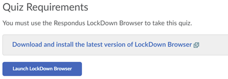

- If you have not already installed the latest version of the LockDown Browser, please do that now and follow the installation instructions. If the LockDown Browser does not download and install properly, please contact Purdue IT. The instructor has limited knowledge for debugging this. - Return to the Quiz page in Brightspace and Launch the LockDown Browser. If it does not launch properly be sure to check the following: 1) That you have no PowerPoint Slides open on your computer, 2) That you only have one monitor active, 3) You do not have any video conferencing open like Zoom, WebEx, or Skype. - The preliminary questions will now start. - Note that the time for the quiz does not start until all of the preliminary information is completed.

### Note:

- LockDown Browser only needs to be installed once to a computer or device. This means that when you click on the link says that it is already installed, the quiz will start.
- DO NOT RUN LOCKDOWN BROWSER DIRECTLY FROM YOUR COMPUTER, only run it through Brightspace, this includes the practice procedure exam.

To ensure LockDown Browser are set up properly, do the following:

- Log into the course
- Open the practice procedure exam and launch LockDown Browser (you do not need to actually start the exam itself)
- Run the System & Network Check. If a problem is indicated, see the ‘Getting Help’ section below.
- Exit the Help Center and start the practice exam.
- Upon completing and submitting the practice quiz, there will be a popup window so that you can exit the LockDown Browser.

I strongly suggest that you take the practice procedure Exam using the same computer and network as you will be using for the exam. If you change computers or networks, please re-take the exam. Your instructor will be checking the monitoring to be sure that the conditions are acceptable before you take the real exam.

## Guidelines

- Ensure you’re in a location where you won’t be interrupted. (online only)
- Turn off all other devices (e.g. tablets, phones, second computers) and place them outside of your reach.
- Do not wear headphones.
- Before starting the test, know how much time is available, and also that you’ve allotted sufficient time to complete it. For exams, you will not be able to type anything after the exam window is closed whether you have taken all of your allotted time or not.
- The exam is closed book and open notes. The only items allowed at your workspace during the exam are **writing utensils, erasers, calculator, notes, and picture ID**. Your cellphone must be packaged away in your backpack and cannot be with you at your desk. In addition, you cannot share anything with anyone else in the room. It is strongly recommend that you create a crib sheet. I suggest that the information be organized so that you can find it easily in the exam setting. For example, use **color coding schemes** to distinguish formulas, definitions, theorems, and techniques. Additionally, **box off sections** to help distinguish different topics. You may have additional paper if you want but these are not required.
- Remain at your computer for the duration of the test.
- If the computer, Wi-Fi, or location is different than what was used previously with the “Webcam Check” and “System & Network Check” in LockDown Browser, run the checks again prior to the exam.
- To produce a good webcam video, do the following:
  - Avoid wearing baseball caps or hats with brims. (online only)
  - Ensure your computer or device is on a firm surface (a desk or table). Do NOT have the computer on your lap, a bed, or other surface where the device (or you) are likely to move.
  - If using a built-in webcam, avoid readjusting the tilt of the screen after the webcam setup is complete. (online only)
  - Take the exam in a well-lit room, but avoid backlighting (such as sitting with your back to a window). (online only)
- Remember that LockDown Browser will prevent you from accessing other websites or applications except for the link to the z-table; you will be unable to exit the test until it is submitted.
- A scientific calculator is available inside the LockDown Browser. But it is recommended that you use a separate calculator that you are familiar with.
- There are special characters that are available inside of the browser. You may use them for Greek letters. I also suggest that you become familiar with the Brightspace editor which allows you to insert special characters and complete mathematical equations.

### Getting Help

Several resources are available if you encounter problems with LockDown Browser:

- The Windows and Mac versions of LockDown Browser have a “Help Center” button located on the toolbar. Use the “System & Network Check” to troubleshoot issues. If an exam requires you to use a webcam, also run the “Webcam Check” from this area.
- You may contact Purdue IT for help.
- Respondus has a Knowledge Base available from support.respondus.com. Select the “Knowledge Base” link and then select “Respondus LockDown Browser” as the product.
- If you’re still unable to resolve a technical issue with LockDown Browser, go to support.respondus.com and select “Submit a Ticket”. Provide detailed information about your problem and what steps you took to resolve it.

## LockDown Browser Menu and Symbols

To ensure clarity regarding the functionalities available within the LockDown Browser, particularly concerning menu options and symbols pertinent to the upcoming midterm preparation, it is important to note that direct digital capture methods, such as screen snipping, are precluded for security reasons. Consequently, a photograph of the screen has been taken and is provided herein for comprehensive insight.

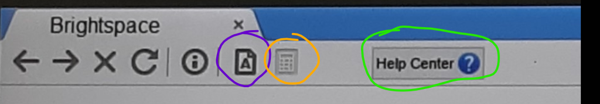

Highlighted in purple (left) are the special characters, detailed further below.

Highlighted in orange (center) is the scientific calculator. While personal preferences may vary regarding the use of computer-based calculators, it is available should you require its assistance.

Highlighted in green (right) is the help center. This section provides a valuable resource for verifying the functionality of your internet and computer system.

### Special Characters:

The images provided below include two screens; the second displays the letters in uppercase, which are generally not utilized in this class.

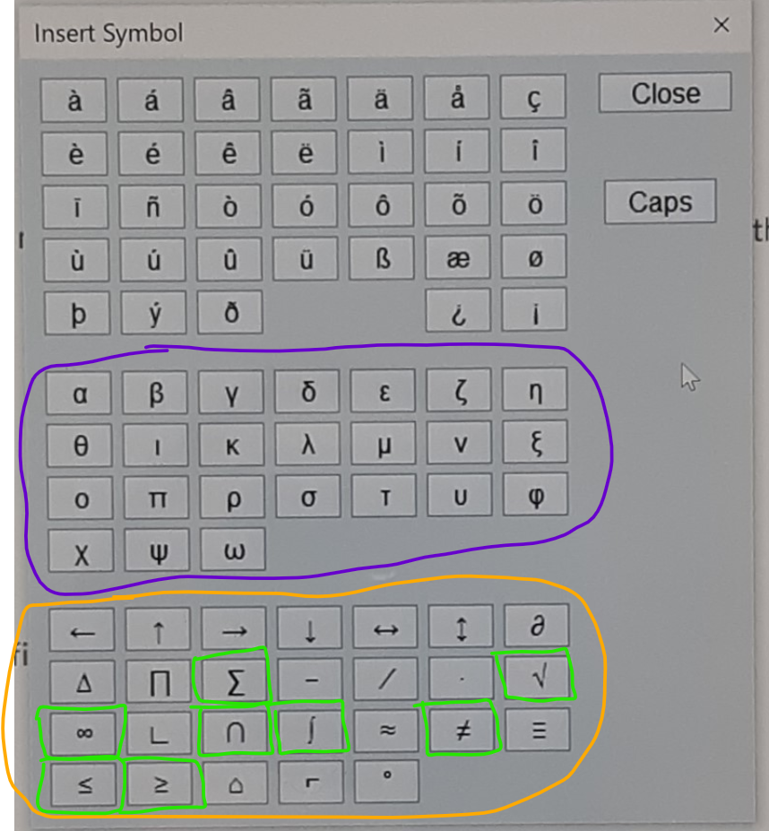

Circled in purple (top) are the Greek letters.

Circle in orange (bottom) are the mathematical symbols that are available.

I have put green squares around the symbols that are more commonly used in this course.

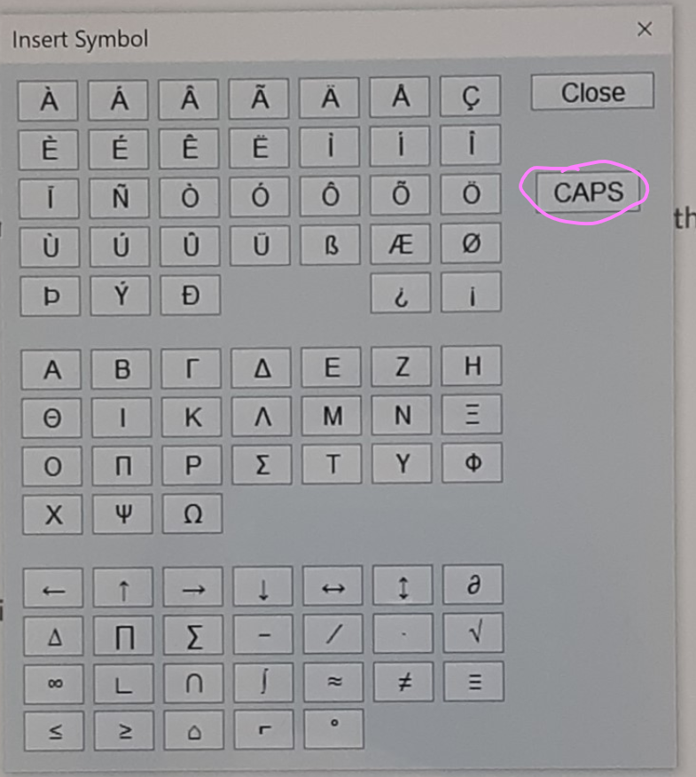

I have circled in pink how to get this screen. The mathematical symbols don’t change and we don’t use a lot of capital Greek letters in this course.

# Exam Grading

For free response problems (only) we grade on **consistency**: Consistency can be helpful if you cannot figure out the answer to an early part of a problem.This means that how you solve one part of a problem can influence the grading of subsequent parts. Consistency can work both in your favor and against you, depending on your approach. Here’s how it works:

- **Positive Impact of Consistency**:
  - **Example Situation**: Consider a problem involving integration, where:
    - Part a) requires you to determine the initial coefficient (normalization coefficient).
    - Part b) asks you to compute a probability based on the coefficient from part a).
  - Grading Approach: If your answer in part a) is incorrect, we will still grade part b) based on your answer to part a). This means you could receive full marks for part b) if your calculations are consistent with the incorrect coefficient you determined in part a).
  - **Note**: It’s crucial to attempt an answer for part a), even if you’re unsure. Any plausible answer could benefit your grade in part b). However, proposing an impossible value (e.g., one that results in a probability density function being negative or zero) will negatively affect your score in both parts.
- **Negative Impact of Consistency**:
  - **Example Situation**: Suppose you are solving a hypothesis testing problem where:
    - Part a) requires you to state the alternative hypothesis, which you specify as a two-sided test ($\neq$).
    - **Subsequent parts**: Later, you calculate a one-sided confidence bound instead of a two-sided confidence interval.
    - **Grading Consequence**: Even if the one-sided confidence bound is technically correct for the problem, you will lose points for inconsistency. This is because your earlier statement of a two-sided alternative hypothesis indicates a different understanding or approach.